# Candy example

Liland

2023-11-15

## Data set

The candy dataset contains sensory assessments of 5 different candies by 11 trained assessors. Each assessor has judged 9 sensory attributes 3 times for each candy on a scale from 0 to 15. The dataset has 165 rows ($5 \times 11 \times 3$) and 2 factors: assessor and candy.

## Linear Mixed Model ANOVA

When analysing the candy dataset using Linear Mixed Model ANOVA (LMM), we focus on one sensory attribute and consider the assessors as a random effect.

```
## Analysis of variance (restricted model)
## Response: assessment
##                Mean Sq  Sum Sq  Df F value Pr(>F)
## candy          1224.18 4896.72   4  153.53 0.0000
## assessor         15.48  154.84  10    2.67 0.0058
## candy:assessor    7.97  318.94  40    1.38 0.0992
## Residuals         5.80  637.59 110       -      -
##
##                  Err.term(s) Err.df VC(SS)
## 1 candy                  (3)     40  fixed
## 2 assessor               (4)    110  0.646
## 3 candy:assessor         (4)    110  0.726
## 4 Residuals                -      -  5.796
## (VC = variance component)
##
##                Expected mean squares
## candy          (4) + 3 (3) + 33 Q[1]
## assessor       (4) + 15 (2)
## candy:assessor (4) + 3 (3)
## Residuals      (4)
```

We observe significant effects of both candy and assessor with P-values < 0.01 and an interaction effect which would be significant at an level of 0.1. From this it is evident that there is great differences between the candies. In addition, the assessors have clear differences in their overall assessments, and to some degree also assess similar candies differently (the weak interaction).

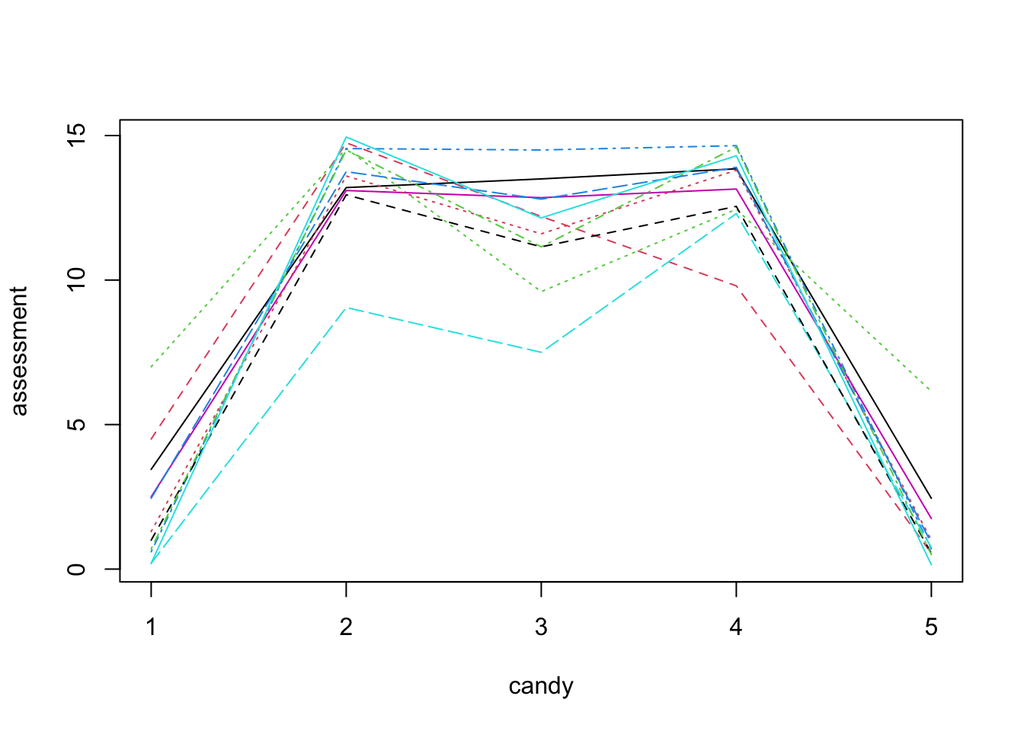

A plot of the predicted candy assessments with one line per assessor confirms the LMM results visually. We observe a general trend in assessments, but also different usage of the assessment scale (some spanning the full scale, some compressing their assessments) and some indidvidual differences for the candies.

```
## Tukey's HSD
## Alpha: 0.05
##
##        Mean G1 G2
## 2 13.540909  A
## 4 13.213636  A
## 3 11.727273  A
## 1  2.172727     B
## 5  1.404545     B
```

The compact letter display reveals two distinct groups of candies. The minimum significant difference of the candies is 1.9854 confirming the groupings found by Tukey’s Honestly Significant Differences.